# Lesson 2: Basic Stats in R

Donny Hoang

3/20/2020

## Goals:

Goal 1: Learn how to organize data, and perform simple statistical analysis in R.

Goal 2: Assess the function (based on COD) of our CR communities.

## Dataset:

We are using data collected from the same experiment as the last lesson. Howevever, instead of pH, I measured the chemical oxygen demand, or COD of all samples from Day 4 of the experiment. COD assays measures the amount of oxygen consumed by a reaction. Thus, if a sample has more COD if has more organic material in it. We are using COD as an approximation for how well communities function. A good performing community will use up more organic material and have less COD. A poor performing community will use up less organic material and have more COD. Here, we want to see if our treatments significantly altered a communities ability to degrade COD.

## Excercises:

# Part 1: load in packages and your data

```r
#Donny Hoang
#3.20.2020
#Graphing COD data

## if the packages are not installed, use these commands to install them
#install.packages('ggpubr')
#install.packages('ggplot2')
#install.packages('dplyr')
#install.packages('reshape2')
library(ggplot2)
library(ggpubr)
library(dplyr)
library(reshape2)


data<-read.csv("COD_day4_percent.csv",header=TRUE)
```

Don’t forget to write some descriptive notes at the top of your script. We are also loading in two new packages, dplyr and reshape2. We will need functions from these packages to manipulate our data later on. Let’s take a look at the data so far.

```r
head(data)
```

```
##   Sample Treatment replicate  day percent_1 percent_2 percent_3
## 1 pH6_4A      pH 6         A four  30.00000  26.51163  28.60465
## 2 pH6_4B      pH 6         B four  26.51163  24.41860  25.81395
## 3 pH6_4C      pH 6         C four  22.32558  25.81395  27.20930
## 4 pH6_4D      pH 6         D four  26.51163  25.11628  23.72093
## 5 pH6_4E      pH 6         E four  23.02326  24.41860  29.30233
## 6 pH6_4F      pH 6         F four  26.51163  27.90698  28.60465
```

```r
summary(data)
```

```
##             Sample                Treatment replicate   day       percent_1
##  10%_glucose_4A: 1   pH 10             :6   A:6       four:36   Min.   :22.33
##  10%_glucose_4B: 1   pH 6              :6   B:6                 1st Qu.:29.76
##  10%_glucose_4C: 1   pH 6 + 10% glucose:6   C:6                 Median :34.68
##  10%_glucose_4D: 1   pH 6 + 5% glucose :6   D:6                 Mean   :38.88
##  10%_glucose_4E: 1   pH 6 + MES        :6   E:6                 3rd Qu.:46.51
##  10%_glucose_4F: 1   pH 8              :6   F:6                 Max.   :66.53
##  (Other)       :30
##    percent_2       percent_3
##  Min.   :24.42   Min.   :23.72
##  1st Qu.:29.17   1st Qu.:29.70
##  Median :33.96   Median :34.17
##  Mean   :38.47   Mean   :39.30
##  3rd Qu.:44.88   3rd Qu.:44.01
##  Max.   :68.98   Max.   :71.02
##
```

What I hope you notice is that we have the same biological replicates as before (A, B, C, etc.) but we also have technical replicate measurements for each sample. That is, every sample has three COD measurements. Additionally, these measurements are expressed as a percentage. This will be important for our interpretation later on.

## Part 2: Organizing the data.

Graphing the data as is can be cumbersome, as it’s raw data and we haven’t yet calculated the mean or standard deviation. First, let’s collapse our columns “percent_1”,“percent_2”, and “percent_3”. To do this, we need the melt() function from the reshape2 package.

```r
data<-melt(data,id=c("Sample", "Treatment", "replicate", "day"))

head(data) ## take a peak at the new data
```

```
##   Sample Treatment replicate  day  variable    value
## 1 pH6_4A      pH 6         A four percent_1 30.00000
## 2 pH6_4B      pH 6         B four percent_1 26.51163
## 3 pH6_4C      pH 6         C four percent_1 22.32558
## 4 pH6_4D      pH 6         D four percent_1 26.51163
## 5 pH6_4E      pH 6         E four percent_1 23.02326
## 6 pH6_4F      pH 6         F four percent_1 26.51163
```

Here, we’ve collapsed the columns “percent_1”,“percent_2”, and “percent_3” into a new column, “variable” and their values are in the new column “value”.

Our next step is to calculate the mean and sd for our groups.However, if we do the calculations now, R will take the mean and sd of ALL the values. This calculation isn’t useful, because we are trying to compare the means between groups. Thus, we must first specify our groups. We can do this using the group_by() function from dplyr, and our friend from last lesson, %>%, from magrittr.

```r
data<-data %>%
  group_by(Treatment, replicate) %>%
  summarise(count=n(),
            mean=mean(value),
            sd=sd(value))

head(data) #take a peak at the data
```

```
## # A tibble: 6 x 5
## # Groups:   Treatment [1]
##   Treatment replicate count  mean    sd
##   <fct>     <fct>     <int> <dbl> <dbl>
## 1 pH 10     A             3  34.4 2.22
## 2 pH 10     B             3  39.0 3.26
## 3 pH 10     C             3  34.7 0.690
## 4 pH 10     D             3  31.7 2.87
## 5 pH 10     E             3  32.8 1.05
## 6 pH 10     F             3  42.2 1.83
```

## Part 3: Graphing the data.

Great! The data is almost ready to be graphed. I’m going to write a couple aesthetic codes. R’s default color palette isn’t that pretty, imo. I like to manually specify my colors to ensure that they’re harmonious and colorblind friendly. Additionally, R will want to order our treatments alphabetically. That order isn’t always how we’ll want it, so we will specify the order we want.

```r
palette <-c( "#56B4E9", "#999999","#E69F00","#0072B2", "#F0E442","#CC79A7") #does this code look similar to something you've seen before?

data$Treatment<-factor(data$Treatment, levels = c("pH 6","pH 6 + MES","pH 6 + 5% glucose",
                                                  "pH 6 + 10% glucose","pH 8","pH 10"))
```

Alright, let’s graph!

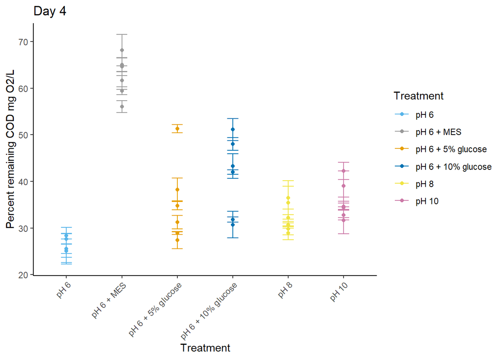

```r
plot <-ggplot(data,aes(x=Treatment, y=mean, color=Treatment))+ #initialize the graph
  geom_point()+ #add points
  scale_colour_manual(values=palette) + #specify colors
  geom_errorbar(aes(ymin=mean-sd, ymax=mean+sd),width=.2, position=position_dodge(.05))+ #add error bars
  labs(title="Day 4", y = "Percent remaining COD mg O2/L") + #add labels
  theme_classic() + #make it pretty
  theme(axis.text.x=element_text(angle=45, hjust=1)) #rotate x-axis labels so they don't overlap

plot
```

Almost done! It looks like there are some differences, but we want to know if they are significant. Remember that we want to know whether any of the treatments result in significantly different remaining COD compared to our control, CR pH 6. That sounds like a t-test, which ggpubr can do and place onto our graph.

## Part 4: Perform a t-test.

First, we must specify our comparisons. Then, we can adjust our graph above with a new line of code.

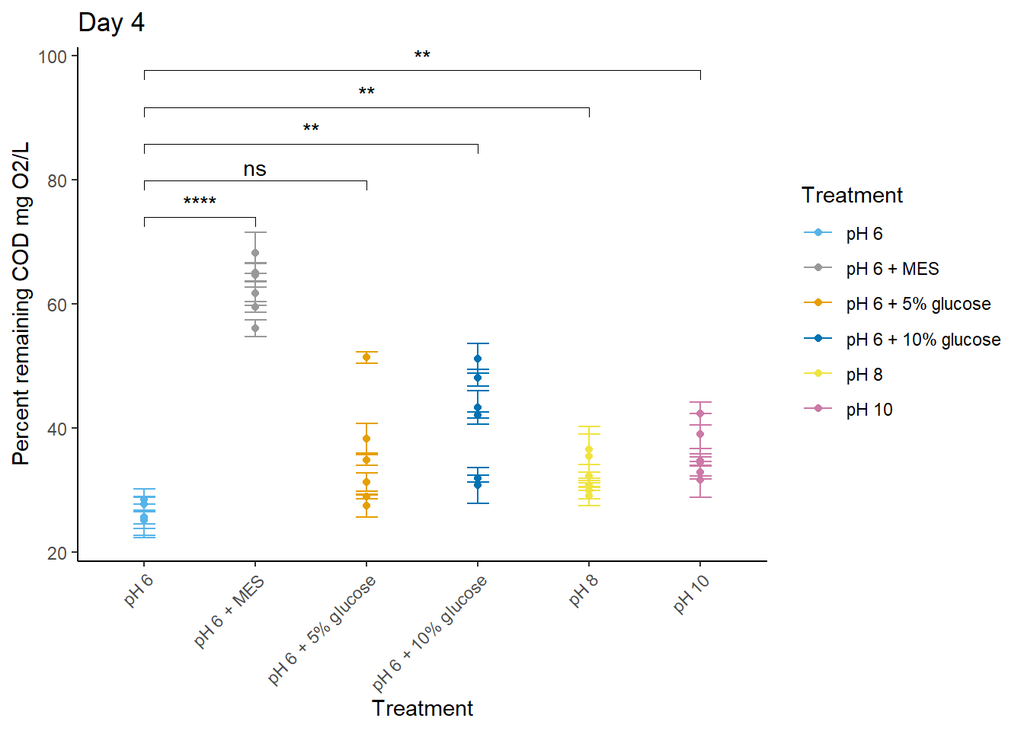

```r
my_comparisons<-list(c("pH 6", "pH 6 + MES"), c("pH 6", "pH 6 + 5% glucose"), c("pH 6", "pH 6 + 10% glucose"), c("pH 6", "pH 8"),  c("pH 6", "pH 10"))

plot <-ggplot(data,aes(x=Treatment, y=mean, color=Treatment))+
  geom_point()+
  scale_colour_manual(values=palette) +
  geom_errorbar(aes(ymin=mean-sd, ymax=mean+sd),width=.2, position=position_dodge(.05))+
  labs(title="Day 4", y = "Percent remaining COD mg O2/L") +
  theme_classic() +
  theme(axis.text.x=element_text(angle=45, hjust=1)) +
  stat_compare_means(comparisons=my_comparisons, method="t.test", label="p.signif") #adding significance

plot
```

You can play around with the comparisons, but the most important comparisons, to me, are pairwise comparisons between CR pH 6 and the other treatments.

We’re ready to interpret the data!

1. How did altering the CR affect the communitys’ ability to degrade CR? Which of those changes are “significant”?
2. Describe the variation in each treatment. What do you think is happening in these communities?
3. We are making a couple assumptions which the data here. Can you think of some caveats to our interpretation? Hint: COD is a proxy for ALL organic material in the media. We spun down the cells and measured the supernantant, so what’s left?
4. The data is expressed as a percentage of remaining COD. How does that limit your interpretation? What kind of measurements or experiments should we do to get past those limitations?

I hope you are getting a bit more comfortable with R. We will do one more lesson graphing lesson before moving on to sequence analysis.